# The Heliotronics Case

Team 2: Elena Pshenichnikova & Lina Simonian

2025-03-13

## Question 1

Use an electronic spreadsheet to plot the data displayed in the table and draw a scatter plot (point diagram).

Does the **multiplicative learning model** which assumes the following relationship:

$$Y = A X^b$$

apply to this data set?

In our case **Y** are the average manufacturing cost of the last batch of 100 solar panels at Heliotronic in $ after having produced a cumulative production of **X** solar panels.

In the table **X** represents the column labeled **total number of solar panels produced** at Heliotronics.

**b** is the **experience parameter** not to be confused with the learning rate.

**A** is the price or **cost of the first unit**.

Obviously,
$$Y = A X^b$$
is **not a linear relationship** of the type that regression analysis can model (**y = a + b₁x₁**).

So the question now is to **transform the data in order to get a linear relationship**.

Make an appropriate transformation of the data and redo the plot with the transformed data.

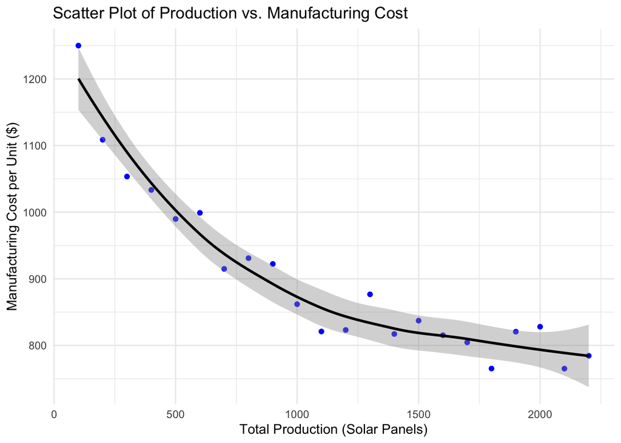

```r
# Step 1
## Plotting the data
## `geom_smooth()` using method = 'loess' and formula = 'y ~ x'
ggplot(Data, aes(x = number_of_solar_panels, y = manufacturing_cost)) +
  geom_point(color = 'blue') +
  geom_smooth(color = 'black')+
  labs(title = "Scatter Plot of Production vs. Manufacturing Cost",
       x = "Total Production (Solar Panels)",
       y = "Manufacturing Cost per Unit ($)") +
  theme_minimal()
```

```r
# Step 2
## Logarithm transformation

Data=Data %>% mutate(Log_number_of_solar_panels=log(number_of_solar_panels))
Data=Data%>% mutate(Log_manufacturing_cost=log(manufacturing_cost))
datatable(Data, options = list(scrollX = TRUE))
```

|  | number_of_solar_panels | manufacturing_cost | Log_number_of_solar_panels | Log_manufacturing_cost |
| --- | --- | --- | --- | --- |
| 1 | 100 | 1250 | 4.605170185988092 | 7.130898830296347 |
| 2 | 200 | 1108.7 | 5.298317366548036 | 7.010943436778306 |
| 3 | 300 | 1053.5 | 5.703782474656201 | 6.959873233244243 |
| 4 | 400 | 1033.4 | 5.991464547107982 | 6.940609615853084 |
| 5 | 500 | 989.8 | 6.214608098422191 | 6.897502902517786 |
| 6 | 600 | 999 | 6.396929655216146 | 6.906754778648554 |
| 7 | 700 | 914.9 | 6.551080335043404 | 6.818814769685489 |
| 8 | 800 | 931 | 6.684611727667927 | 6.836259277277067 |
| 9 | 900 | 922.3 | 6.802394763324311 | 6.826870550241673 |
| 10 | 1000 | 861.9 | 6.907755278982137 | 6.759139254653354 |

[output cut: 12 more lines]

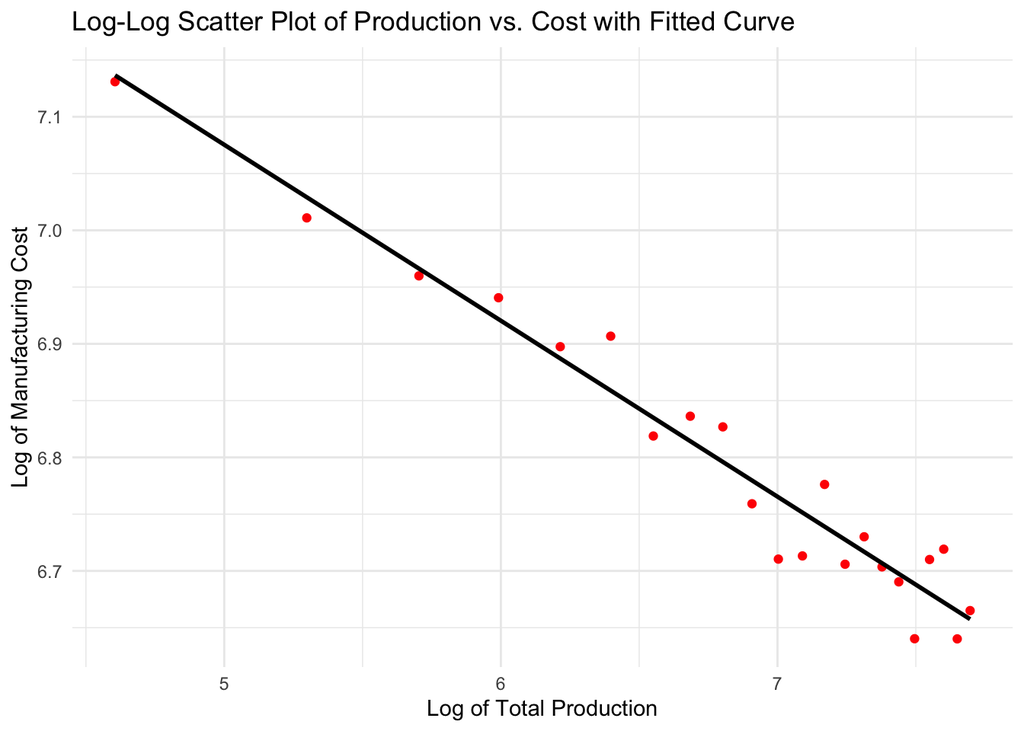

```r
# Step 3
## Plotting transformed data
ggplot(Data, aes(x = Log_number_of_solar_panels, y = Log_manufacturing_cost)) +
  geom_point(color = 'red') +
  geom_smooth(method = "lm", color = 'black', se = FALSE) +
  labs(title = "Log-Log Scatter Plot of Production vs. Cost with Fitted Curve",
       x = "Log of Total Production",
       y = "Log of Manufacturing Cost") +
  theme_minimal()
```

By taking the natural logarithm of both sides we converted the power-law function into a linear relationship.

## Question 2

Once you have answered the above questions, **conduct a linear regression with the transformed data**:  
**Use R** to estimate the **regression model**.

Please **interpret the results of the regression analysis**! How well does the model explain the data?

What is the **learning rate** that applies in this case?

```r
# Fit the log-log regression model
model <- with(Data, lm(Log_manufacturing_cost ~ Log_number_of_solar_panels))

# Display the summary of the model
summary(lm.beta(model))
```

```
##
## Call:
## lm(formula = Log_manufacturing_cost ~ Log_number_of_solar_panels)
##
## Residuals:
##       Min        1Q    Median        3Q       Max
## -0.054515 -0.019960 -0.004477  0.021216  0.047893
##
## Coefficients:
##                             Estimate Standardized Std. Error t value Pr(>|t|)
## (Intercept)                 7.850325           NA   0.054409  144.28  < 2e-16
## Log_number_of_solar_panels -0.154991    -0.974768   0.007936  -19.53  1.7e-14
##
## (Intercept)                ***
## Log_number_of_solar_panels ***
## ---
## Signif. codes:  0 '***' 0.001 '**' 0.01 '*' 0.05 '.' 0.1 ' ' 1
##
## Residual standard error: 0.0299 on 20 degrees of freedom
## Multiple R-squared:  0.9502, Adjusted R-squared:  0.9477
## F-statistic: 381.4 on 1 and 20 DF,  p-value: 1.701e-14
```

This regression model estimates the relationship between **log-transformed manufacturing cost** and **log-transformed number of solar panels produced** to determine whether the **multiplicative learning model** applies.

#### **Model Equation**

The estimated regression equation is:

$$\log(\text{Manufacturing Cost}) = 7.8503 - 0.155 \times
\log(\text{Number of Solar Panels})$$

#### **Model Fit: How Well Does the Model Explain the Data?**

| Metric | Value | Interpretation |
| --- | --- | --- |
| **Multiple R²** | **0.9502** | The model explains **95.02% of the variation** in manufacturing cost. |
| **Adjusted R²** | **0.9477** | Very close to R², meaning the model is strong even after adjusting for complexity. |
| **F-statistic** | **381.4** | Very high value, confirming the model is statistically significant. |
| **p-value** | **1.701e-14 (< 0.001)** | The model is highly significant, meaning there is a strong relationship between production and cost. |
| **Residual Standard Error** | **0.0299** | Small residual error, indicating accurate predictions. |

**Conclusion:**  
- The model **fits the data well**. - **95% of the cost variation** is explained by production volume. - The **negative slope confirms cost reduction with increased production**.

#### **Learning Rate (LR) Calculation**

**Computing Log of Cost at** $X$
$$\log(Y_x) = b_0 + b_1 \cdot \log(X)$$

```r
#Step 1
# Extract the maximum X (log scale)
X_log <- max(Data$Log_number_of_solar_panels)  # Using max log-transformed production level

# Compute log(Yx) using the regression model
log_Yx <- 7.8503 + (-0.154991 * X_log)  # Using  log-transformed X
Yx <- exp(log_Yx)  # Convert back from log(Y) to actual cost
```

```
## Production Level (Log_X): 7.696213
```

```
## Manufacturing Cost at X accordingly to the model: 778.57
```

**Computing Log of Cost at $2X$**
$$\log(Y_2x) = b_0 + b_1 \cdot \log(2X)$$

```r
#Step 2
# Define regression coefficients
b0 <- 7.8503  # Intercept
b1 <- -0.154991  # Slope

# Compute log(Y2x) for doubled production (2X)
X2_log <- X_log + log(2)  # Since log(2X) = log(X) + log(2)
log_Y2x <- b0 + (b1 * X2_log)
Y2x <- exp(log_Y2x)  # Convert back from log(Y) to actual cost
```

```
## Doubled Production Level (Log_2X): 8.38936
```

```
## Manufacturing Cost at 2X accordingly to the model: 699.26
```

**Computing Learning Rate (LR)** The learning rate formula is:
$$LR = 1 - \frac{Y_{2X}}{Y_X}$$

```r
#Step 3
# Compute Learning Rate (LR)
learning_rate <- 1 - (Y2x / Yx)
```

```
## Estimated Learning Rate (LR): 10.19 %
```

**Interpretation:** - Learning Rate (LR) = 10.19% - This means that when production doubles from 2200 to 4400 units, the manufacturing cost per unit decreases by 10.19%.

## **Question 3**

Please **use the experience curve** estimate from the regression model to calculate the expected **average manufacturing cost per solar panel for the 400 solar panels** that would be produced for Switzerland.

**Hint**: estimate the average production cost per solar panel for **4700, 4800, 4900 and 5000 units and compute their mean**.

Predict Costs for 4700, 4800, 4900, and 5000 Units:

```r
#Step 1
# Define production levels for prediction
production_values <- c(4700, 4800, 4900, 5000)

# Compute predicted log cost
log_predicted_costs <- b0 + b1 * log(production_values)  # Natural log used

# Convert back from log cost to actual cost ($)
predicted_costs <- exp(log_predicted_costs)

# Print predicted costs
df <- data.frame(number_of_solar_panels = production_values, manufacturing_cost = round(predicted_costs, 2))
datatable(df, options = list(scrollX = TRUE, pageLength = 5))
```

|  | number_of_solar_panels | manufacturing_cost |
| --- | --- | --- |
| 1 | 4700 | 692.15 |
| 2 | 4800 | 689.89 |
| 3 | 4900 | 687.69 |
| 4 | 5000 | 685.54 |

- Calculate the expected average manufacturing cost per solar panel for the 400 solar panels:

```r
#Step 2
# Compute the mean predicted cost
avg_cost <- mean(predicted_costs)
```

```
## Average Manufacturing Cost per Solar Panel: $ 688.82
```

## **Question 4**

Please **calculate a 95% confidence interval for the average manufacturing cost per solar panel** for the panels produced for Switzerland by using the lower and upper bounds of the confidence interval estimate for the experience parameter.

You should calculate **two extra regression equations** for both limits and then calculate the expected **average manufacturing cost per solar panel** for the **400 solar panels** that would be produced for Switzerland as in exercise 3.

Extracting 95% Confidence Interval for the Experience Parameter:

```r
#Step 1
# Extract the 95% confidence interval for the slope (b1)
conf_int <- confint(model)

# Lower and Upper Bound for experience parameter (b1)

b0_LB <- conf_int[1, 1]
b0_UB <- conf_int[1, 2]
b1_LB <- conf_int[2, 1]
b1_UB <- conf_int[2, 2]
```

Apply Confidence Interval Bounds:

```r
#Step 2
# Compute log costs using the confidence interval bounds (without repeating predictions)
log_cost_LB <-  b0_LB + b1_LB * log(production_values)
log_cost_UB <- b0_UB + b1_UB * log(production_values)

# Convert back to actual cost ($)
cost_LB <- exp(log_cost_LB)
cost_UB <- exp(log_cost_UB)

# Store results in a data frame
predicted_costs_CI <- data.frame(
  number_of_solar_panels = production_values,
  manufacturing_cost_LB = round(cost_LB, 2),
  manufacturing_cost_UB = round(cost_UB, 2)
)

# Display results
predicted_costs_CI
```

```
##   number_of_solar_panels manufacturing_cost_LB manufacturing_cost_UB
## 1                   4700                537.19                891.85
## 2                   4800                535.26                889.26
## 3                   4900                533.37                886.72
## 4                   5000                531.52                884.25
```

Compute the Average Cost for LB and UB:

```r
#Step 3
# Compute the mean predicted cost for LB and UB
mean_cost_LB <- mean(cost_LB)
mean_cost_UB <- mean(cost_UB)
```

```
## 95% Confidence Interval for Average Manufacturing Cost per Solar Panel:
```

```
## Lower Bound (LB): $ 534.33
```

```
## Upper Bound (UB): $ 888.02
```

## **Conclusion: Estimating Productivity Gains for Heliotronics’ Swiss Bid**

Based on our **experience curve analysis**, we estimate the **expected manufacturing cost reduction** for Heliotronics as they scale production before producing **400 solar panels for the Swiss canton of Tessin**.

### **Experience Curve Validation**

The **log-log transformation produced a linear relationship**, confirming that Heliotronics’ **manufacturing cost reductions follow a power-law experience curve**.  
The estimated **learning rate (~10.19%)** indicates that **cost per panel decreases by approximately 10% every time cumulative production doubles**.

### **Cost Projection for Switzerland (400 Panels in April 2022)**

Heliotronics will have produced **2,400 additional solar panels before starting production for Switzerland**.  
Using the **experience curve model**, we estimated the expected **average cost per solar panel** at that stage.  
The **predicted cost was computed using cumulative production levels (4700–5000 panels)**, providing a **data-driven estimate for competitive bidding**.

## **Conclusion: Estimating Cost & Bid Strategy for Switzerland**

Our analysis confirms that **Heliotronics’ manufacturing cost follows an experience curve**, with an estimated **learning rate of ~10.19%**. This means that **each time cumulative production doubles, per-unit costs decrease by approximately 10%**.

### **Projected Cost for the Swiss Bid**

**By the time Heliotronics produces the 400 solar panels for Switzerland, total production will have increased by 2,400 units.**  
**Based on the experience curve model, the estimated manufacturing cost per panel falls within the following range:**

**95% Confidence Interval for Cost per Solar Panel: [$534.33 - $888.02]**

### **Recommended Bid Strategy**

**A bid closer to $534.33 would maximize competitiveness**, making Heliotronics a strong contender in the Swiss market.  
**A bid near $888.02 provides a buffer against cost uncertainties**, ensuring sustainable profit margins.  
**Strategic Recommendation:** To balance **competitiveness and profitability**, **Heliotronics should place a bid between $534.33 and $888.02**, considering market conditions and pricing strategy.